# Implementing Popular ML Algorithms in R

November 18, 2017

## Materials

https://github.com/ksasso/MLmodels_inR_GDG2017

## Machine Learning Types and Algorithms

**Supervised**:

- The outcome (or dependent variable, DV) is known or observed
- DV is predicted from independent variables (IVs or predictors)
- Training until a desired level of accuracy is reached
- Some examples
  - Regression, Random Forest, KNN (k-nearest-neighbor)

**Unsupervised**:

- The outcome or DV is not known (no target or outcome to predict)
- Often used for clustering population into different groups
- Examples:
  - Various clustering algorithms (K-means), NLP algorithms (Latent Dirichlet Allocation or LDA)

## Resampling Methods

- Prediction error
  - The deviation of actual values from the predicted values
  - Calculating this using the same observations used to train the model can lead to underestimating the prediction error
- Resampling Methods
  - Refit a model of interest to a second set of observations, or a test set
  - Predicting responses of new observations, that were not used in training the model
  - Way of reducing bias when evaluating model fit
- Validation-set approach
  - Randomly divide the available sample into a training set and a hold-out set
  - Fit model to training set, use fitted model to predict responses from the test set
  - Test error can be highly variable, depending on which obs are included
- *K*-fold Cross-Validation (CV)
  - Randomly divide the data into *K* equal-sized parts.
  - Leave out part *k*, fit the model to the other *K*-1 parts (combined) and obtain predictions for the left-out *k* th part.
  - Each "fold" gets a turn as a training and test set and prediction error is calculated. Combine results to assess overall prediction error

## Tree-based methods for regression and classification:

- CART (Classification and Regression Trees)
  - Involve stratifying or segmenting the predictor space into a number of simple regions
  - The set of rules used to segment the predictor space can be summarized in a tree
  - Tree-based methods are simple and useful for interpretation but not as competitive with the best supervised learning approaches in terms of prediction *but can be* when they are combined (i.e., bagging, random forests, boosting)

## Regression Trees: The Basics\(^{1}\)

**Baseball Salary Data: How Would you Stratify it?**

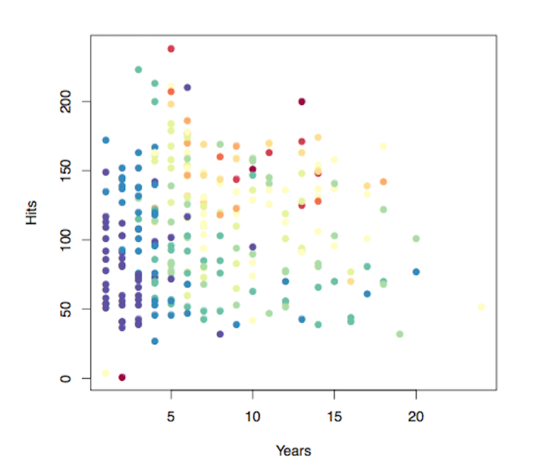

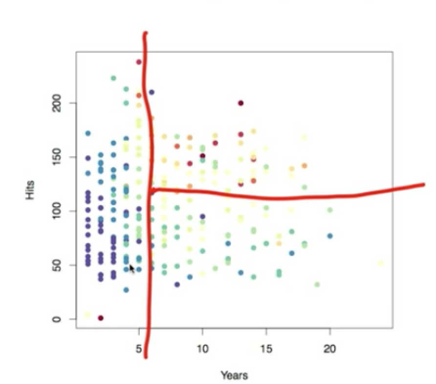

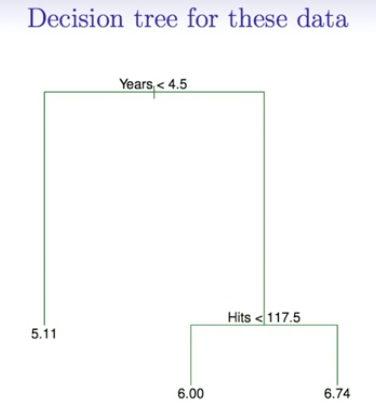

\(^{1}\)

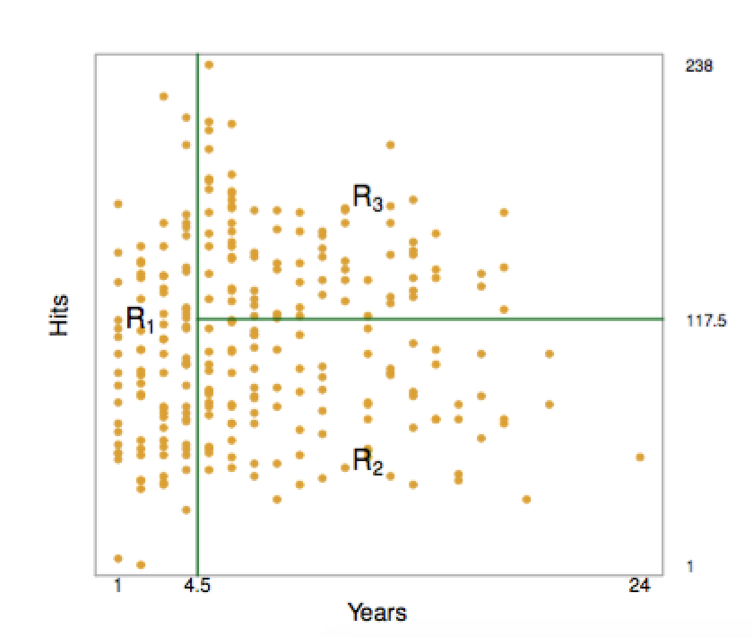

**GOAL**\(^{1}\):

Find boxes \(R_{1},...,R_{J}\) that minimize the RSS, given by \[ \sum_{j = 1}^{J}\sum_{i \in R_{j}}(y_{i}-\hat{y}_{R_{j}})^{2} \] where \(\hat{y}_{R_{j}}\) is the mean response for the training observation within the *j* th box

## Ensemble Methods to improve accuracy

**Bootstrapping/Bagging**\(^{1}\):

- Take repeated samples from the training data set
- Generate B different bootstrapped training data sets and grow a tree on each
  - Take the average of all predictions from each bootstrapped training set (or for classification take the majority vote)
  - Can compute out-of-bag error estimate (i.e., like cross-validation)

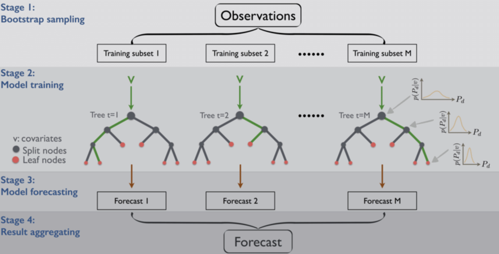

\(^{2}\)

## Ensemble Methods to Improve Accuracy\(^{1}\)

**Boosting**:

- Similar to bagging except that the trees are grown *sequentially* using information from previously grown trees VS. Bagging where each tree is built on a bootstrapped df independent of other trees
- Each new tree is built to emphasize the observations that the previous trees mis-classified in order to improve on performance of the previous mix of trees
  - We do this by fitting small trees to the residuals to slowly improve \(\hat{f}\) where it isn't performing well.
- Given sequential fitting and shrinkage parameters don't need to grow as large of trees.
- Set \(\hat{f}_{1}(x)=0\) and \(r_{i} = y_{i}\) for all *i* in the training set at stage one
- For *k* = 1,2,…, *K*, repeat:
  - Fit a tree \(\hat{t}^{k}\) with *d* splits to the training data
  - Update \(\hat{f}\) by adding in a shrunken version of the new tree \[ \hat{f}_{k+1}(x_{i}) \leftarrow \hat{f}_{k}(x_{i}) + \lambda\hat{t}_{k}(x_{i}) \]
  - Update the residuals \[ r_{i},_{k+1}\leftarrow r_{i},_{k}-\lambda\hat{f}_{k}(x_{i}) \]
  - Output the boosted model \[ \hat{f}(x) = \sum_{k=1}^{K}\lambda\hat{t}_{k}(x) \]

## Ensemble Methods to improve accuracy\(^{1}\)

**A number of tuning parameters for Boosting Models**:

- Number of trees *B*
  - Way to control over fitting.
  - Use cross-val to select *B*
- Shrinkage Parameter \(\Lambda\)
  - small positive number.
  - Controls the rate at which boosting learns (i.e., .01, .001)
- Depth *d*
  - number of splits in each tree
  - Try a few values (1,2,4,8).

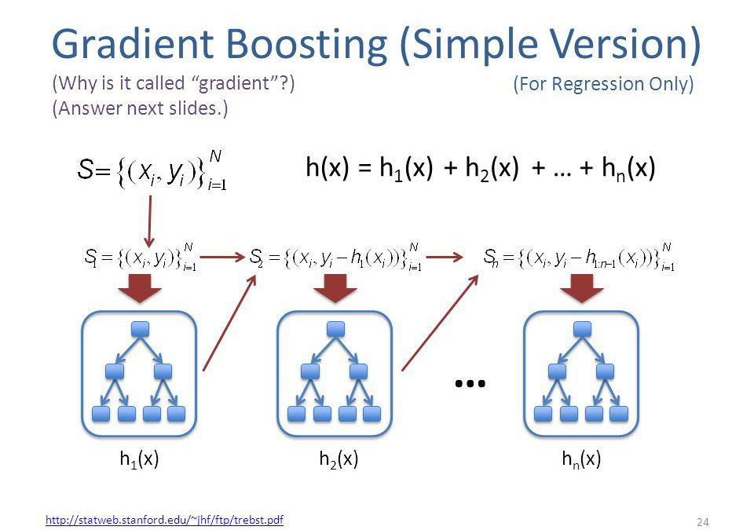

\(^{3}\)

## Random Forests and Boosting: "Leveraging" Multiple Decision Trees

**Combine Regression Trees, Bagging or Boosting, and Some Tweaks to Improve Accuracy**

*Random Forests*:

- Combine decision trees with bagging to achieve very high accuracy
- Similar to the Bagging with the addition of a small tweak that decorrelates trees
  - Each time a split is considered only *m* predictors chosen as split candidate from the full set of predictors and the split is only allowed to use one of them.
  - Fresh selection taken at each split
  - *m* can take on different values, typically \(m\approx \sqrt{p}\)
- Don't have to use pruning (i.e., fully grown trees)

*Ensemble of Decision Trees + Boosting*:

- Basically what was described above. Based on *weak* learners or shallow trees.

## Sometimes simple is better\(^{1}\)

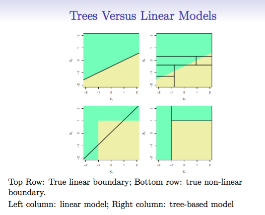

## Interpreting the Black Box

**For bagged/RF and boosting**:

- Regression:
  - The total amount that the RSS is decreased due to splits over a given predictor, averaged over all trees. Large = Important
- Classification:
  - The total amount a similar error measures (i.e., Gini index, entropy) is decreased by splits over a given predictor, averaged over all trees

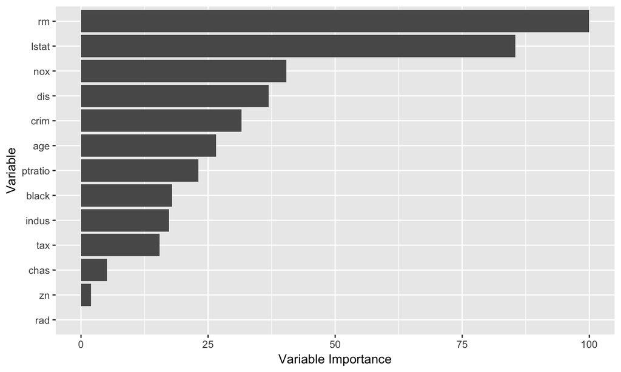

## Favorite Resouces: Machine Learning Concepts

**Nuts and Bults**

- "An Introduction to Statistical Learning (ISL)" by James, Witten, Hastie and Tibshirani
  - Available for free online
  - The best, in my opinion, clear overview of several foundational ML concepts
  - More approachable videos, code, and slides found [here](https://www.r-bloggers.com/in-depth-introduction-to-machine-learning-in-15-hours-of-expert-videos/)
- Andrew Ng's Machine Learning Course on Coursera
  - Great online course to really understand the fundamentals
  - Free (unless you want "certificate") and readily available [here](https://www.coursera.org/learn/machine-learning)
  - Be prepared for some math

**Quicker Crash Courses**

- [Data Camp Caret Course](https://www.datacamp.com/)
  - Great for learning R in general, but specific course on the Caret Package
  - ~$30 monthly subscription (can sometimes access first portal for free)
- [Super High-level on-line Blog Post](https://www.analyticsvidhya.com/blog/2017/09/common-machine-learning-algorithms/)
  - Truly the bare minimum in terms of background, but covers a lot of ground
  - Enough to get started and good code examples in Python and R

## Favorite Resouces: Visualization and Understanding

[**xgboostExplainer**](https://medium.com/applied-data-science/new-r-package-the-xgboost-explainer-51dd7d1aa211):

- New package that makes your XGBoost model "as interpretable as a single decision tree"

[**LIME**](https://cran.r-project.org/web/packages/lime/index.html):

- Local Interpretable Model-Agnostic Explanations\(^{4}\)
- Nice tutorial [here](https://www.r-bloggers.com/explaining-complex-machine-learning-models-with-lime/)
- Broad capabilities *for classification*: can apply with any model for which you can obtain prediction probabilities

[**ICEbox**](https://github.com/kapelner/ICEbox)\(^{5}\):

- Allow you to visualize the model estimated by any supervised learning algorithm
- Classical partial dependence plots (PDPs) help visualize the average partial relationship between the predicted response and one or more features, *particularly in the presence of substantial interaction effects*
- [Good overview of this and similar resources](https://www.r-bloggers.com/beyond-beta-relationships-between-partialplot-icebox-and-predcomps/)

## JUST GIVE ME A BUTTON

[h2o auto ML](https://cran.r-project.org/web/packages/h2o/h2o.pdf):

- Available in multiple language and for multiple platforms
- h2o has FAR MORE capabilities than this "h2o.automl" function and is definitely worth checking out
- automl function automates the supervised machine learning model training process fir a number of models
- [Nice tutorial here](http://www.business-science.io/business/2017/09/18/hr_employee_attrition.html)
  - **Disclaimer** in my experience there are few data sets that come ready for a function like this without pre-processing. *Garbage in - garbage out*

## Shameless Plug

[Women in Analytics Conference](https://www.womeninanalytics.org/):

- 3/15/18 in Columbus
- All day conference packed with technical and strategic talks from speakers all over the country
- Get your tickets now, apply for one of our remaining speaker spots, or our data viz competition
- Also check out the great ways to attend for free

[figure not shown]

## Citations

\(^{1}\) James, G., Witten, D., Hastie, T., & Tibshirani, R. (2013). *An introduction to statistical learning (Vol. 112)*. New York: springer.

\(^{2}\) He, X., Chaney, N. W., Schleiss, M., & Sheffield, J. (2016). Spatial downscaling of precipitation using adaptable random forests. *Water Resources Research, 52(10)*, 8217-8237.

\(^{3}\) https://dimensionless.in/gradient-boosting/

\(^{4}\) Ribeiro, M. T., Singh, S., & Guestrin, C. (2016, August). Why should i trust you?: Explaining the predictions of any classifier. *In Proceedings of the 22nd ACM SIGKDD International Conference on Knowledge Discovery and Data Mining (pp. 1135-1144)*. ACM. Chicago

\(^{5}\) Goldstein, A., Kapelner, A., Bleich, J., & Pitkin, E. (2015). Peeking inside the black box: Visualizing statistical learning with plots of individual conditional expectation. *Journal of Computational and Graphical Statistics, 24(1)*, 44-65. Chicago